# Validation file for Equivalence Functions

# **Tests against Literature, existing packages, and MiniTab**

Below I reproduce some examples from the literature, compare TOSTER against other R packages that have equivalence test functions, and against Minitab. MiniTab software has implemented equivalence tests and power analysis for one-sample, independent, and paired t-tests. It is excellent - by far the most user-friendly software for anyone who prefers a commercial statistics program over an open source solution (it also has equivalence tests for 2x2 crossover designs, but not for correlations or meta-analysis). It also allows users to enter summary statistics, which is used here to compare the output of the equivalence functions in TOSTER against minitab. Note that when SD = 1, the mean difference equals the standardized difference. The MiniTab output is followed by the R function.

# **TOST for two independent samples**

## *Example 1.1*

From page 196 of Stegner, B. L., Bostrom, A. G., & Greenfield, T. K. (1996). Equivalence testing for use in psychosocial and services research: An introduction with examples. Evaluation and Program Planning, 19(3), 193-198. https://doi.org/10.1016/0149-7189(96)00011-0

Randomized controlled trial of two conditions of case management, with the main dependent variable being ratings on the Brief Psychiatric Rating Scale (BPRS). The means, sd’s, and sample sizes are:

Control: M = 1.5679, SD = 0.4285, n = 64 Experimental: M = 1.6764, SD = 0.4748, n = 70

Calculated t-values for TOST are t1 = 5.383 and t2 = -2.616

These results can be reproduced with TOSTER package and the TOSTtwo.raw R code:

```r
require(TOSTER)
TOSTtwo.raw(m1=1.5679,m2=1.6764,sd1=0.4285,sd2=0.4748,n1=64,n2=70,low_eqbound=-0.3136, high_eqbound=0.3136,alpha=0.05, var.equal=TRUE)
```

```
## Using alpha = 0.05 Student's t-test was non-significant, t(132) = -1.384005, p = 0.1686925
```

```
## Using alpha = 0.05 the equivalence test based on Student's t-test was significant, t(132) = -2.616216, p = 0.004963596
```

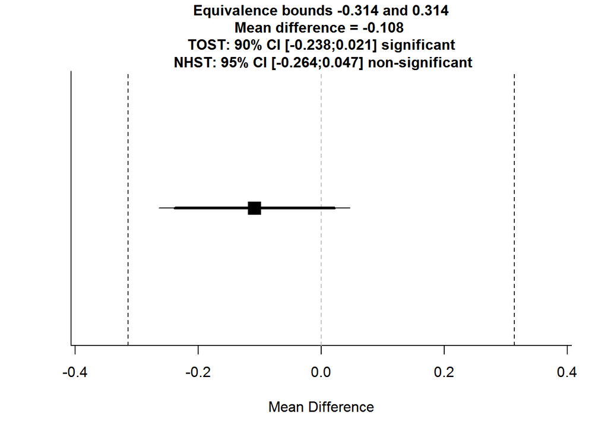

```
## TOST results:
##   t-value 1    p-value 1 t-value 2   p-value 2  df
## 1  5.384227 1.612713e-07 -2.616216 0.004963596 132
##
## Equivalence bounds (raw scores):
##   low bound raw high bound raw
## 1       -0.3136         0.3136
##
## TOST confidence interval:
##   Lower Limit 90% CI raw Upper Limit 90% CI raw
## 1             -0.2383608             0.02136078
```

## *Example 1.2*

From page 225 of Limentani, G. B., Ringo, M. C., Ye, F., Bergquist, M. L., & MCSorley, E. O. (2005). Beyond the t-test: statistical equivalence testing. Analytical Chemistry, 77(11), 221-A.

Reproducing the 90% CI and significant equivalence test.

```r
TOSTtwo.raw(m1=89.3,m2=87.7,sd1=1.9,sd2=1.3,n1=12,n2=12,low_eqbound=-3.7, high_eqbound=3.7,alpha=0.05, var.equal=TRUE)
```

```
## Using alpha = 0.05 Student's t-test was significant, t(22) = 2.407535, p = 0.02488925
```

```
## Using alpha = 0.05 the equivalence test based on Student's t-test was significant, t(22) = -3.15989, p = 0.002270472
```

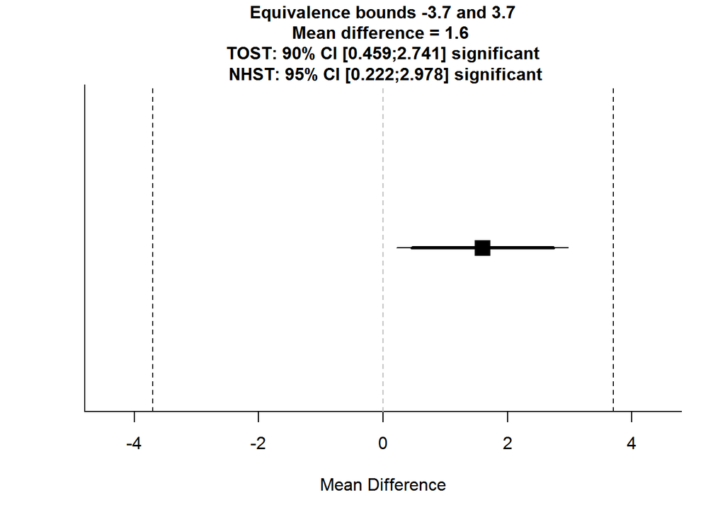

```
## TOST results:
##   t-value 1    p-value 1 t-value 2   p-value 2 df
## 1  7.974961 3.109178e-08  -3.15989 0.002270472 22
##
## Equivalence bounds (raw scores):
##   low bound raw high bound raw
## 1          -3.7            3.7
##
## TOST confidence interval:
##   Lower Limit 90% CI raw Upper Limit 90% CI raw
## 1              0.4588201                2.74118
```

# *Example 1.3*

From Meyners, M. (2012). Equivalence tests - A review. Food Quality and Preference, 26(2), 231-245. https://doi.org/10.1016/j.foodqual.2012.05.003, page 237:

We can use the TOST procedure for an independent t-test to reproduce the p-values and 90% CI:

```r
TOSTtwo.raw(m1=7.1, m2=6.9, sd1=sqrt(2.0), sd2=sqrt(2.2), n1=100, n2=100,low_eqbound=-0.5, high_eqbound=0.5,alpha=0.05, var.equal=TRUE)
```

```
## Using alpha = 0.05 Student's t-test was non-significant, t(198) = 0.9759001, p = 0.3303048
```

```
## Using alpha = 0.05 the equivalence test based on Student's t-test was non-significant, t(198) = -1.46385, p = 0.07241035
```

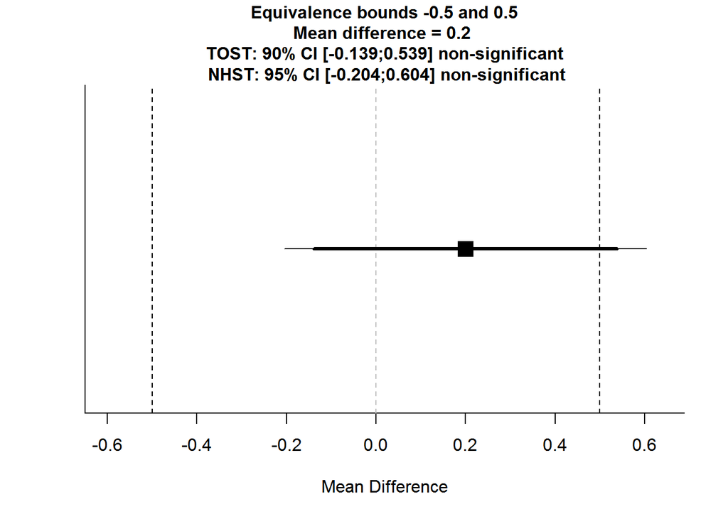

```
## TOST results:
##   t-value 1    p-value 1 t-value 2  p-value 2  df
## 1   3.41565 0.0003859877  -1.46385 0.07241035 198
##
## Equivalence bounds (raw scores):
##   low bound raw high bound raw
## 1          -0.5            0.5
##
## TOST confidence interval:
##   Lower Limit 90% CI raw Upper Limit 90% CI raw
## 1             -0.1386793              0.5386793
```

## *Example 1.4*

From Table 1 in Quertemont, E. (2011). How to Statistically Show the Absence of an Effect. Psychologica Belgica, 51(2), 109. https://doi.org/10.5334/pb-51-2-109

Example 1: t(8) = 1.52; p = 0.92 Example 2: t(298) = -2.23; p = 0.013

```r
#Example 1
TOSTtwo.raw(m1=459.09, m2=402.61, sd1=47.53, sd2=38.42, n1=5, n2=5, low_eqbound=-15, high_eqbound=15,alpha=0.05, var.equal=TRUE)
```

```
## Using alpha = 0.05 Student's t-test was non-significant, t(8) = 2.066441, p = 0.07262966
```

```
## Using alpha = 0.05 the equivalence test based on Student's t-test was non-significant, t(8) = 1.517634, p = 0.916208
```

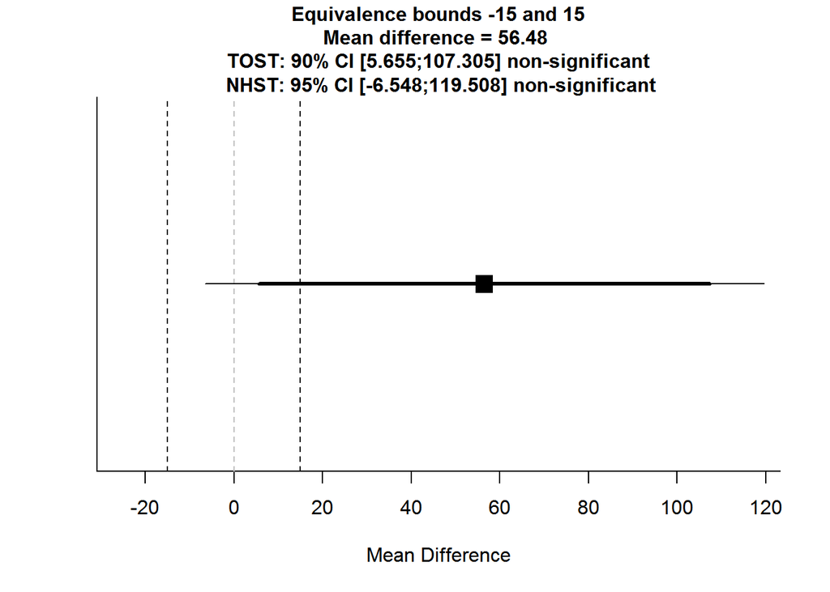

```
## TOST results:
##   t-value 1  p-value 1 t-value 2 p-value 2 df
## 1  2.615247 0.01543878  1.517634  0.916208  8
##
## Equivalence bounds (raw scores):
##   low bound raw high bound raw
## 1           -15             15
##
## TOST confidence interval:
##   Lower Limit 90% CI raw Upper Limit 90% CI raw
## 1               5.654791               107.3052
```

```r
#Example 2
TOSTtwo.raw(m1=407.24, m2=402.98, sd1=41.77, sd2=41.79, n1=150, n2=150, low_eqbound=-15, high_eqbound=15,alpha=0.05, var.equal=TRUE)
```

```
## Using alpha = 0.05 Student's t-test was non-significant, t(298) = 0.8830225, p = 0.3779359
```

```
## Using alpha = 0.05 the equivalence test based on Student's t-test was significant, t(298) = -2.226212, p = 0.0133738
```

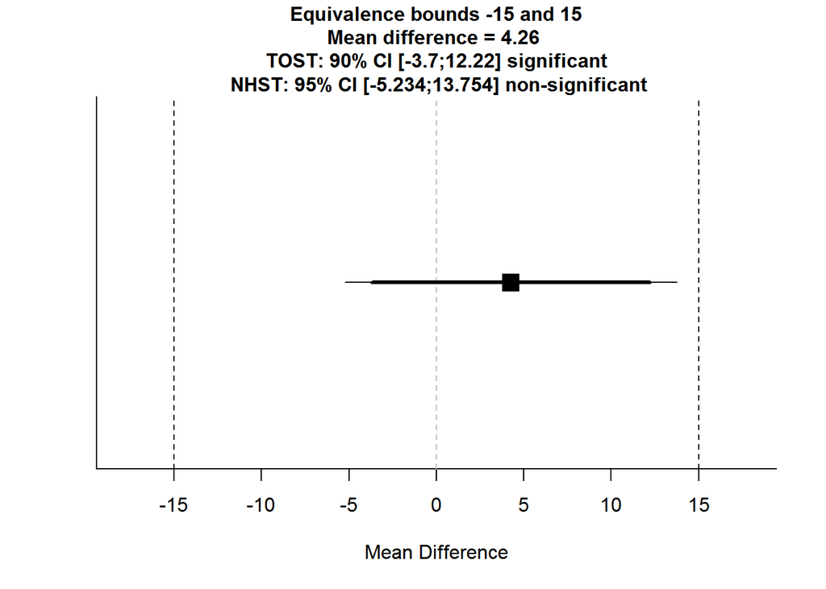

```
## TOST results:
##   t-value 1    p-value 1 t-value 2 p-value 2  df
## 1  3.992257 4.123961e-05 -2.226212 0.0133738 298
##
## Equivalence bounds (raw scores):
##   low bound raw high bound raw
## 1           -15             15
##
## TOST confidence interval:
##   Lower Limit 90% CI raw Upper Limit 90% CI raw
## 1              -3.700077               12.22008
```

These results perfectly match those in Table 1 of Quertemont (2011).

## *Example 1.5*

MiniTab by default uses Welch’s t-test when testing for equivalence, which does not require the assumption of equal variances, which matters with unequal sample sizes. TOSTER also presents Welch’s t-test by default. Note that minitab rounds degrees of freedom down to a whole number. This is a conservative procedure. TOSTER does not. The difference is rarely noticable.

### MiniTab Result Two-Sample Equivalence Test

*Method

Test mean = mean of Test Reference mean = mean of Reference Equal variances were not assumed for the analysis.

Descriptive Statistics

Variable N Mean StDev SE Mean Test 86 2,5 1,3 0,14018 Reference 102 2,3 1,1 0,10892

Difference: Mean(Test) - Mean(Reference)

Difference SE 95% CI Equivalence Interval 0,20000 0,17752 (-0,093626; 0,49363) (-0,4; 0,4)

CI is not within the equivalence interval. Cannot claim equivalence.

Test

Null hypothesis: Difference < or = -0,4 or Difference > or = 0,4 Alternative hypothesis: -0,4 < Difference < 0,4 alpha level: 0,05

Null Hypothesis DF T-Value P-Value Difference < or = -0,4 167 3,3799 0,000 Difference > or = 0,4 167 -1,1266 0,131

The greater of the two P-Values is 0,131. Cannot claim equivalence.

### Reproduce results in TOSTER

```r
TOSTtwo.raw(m1=2.5,m2=2.3,sd1=1.3, sd2=1.1,n1=86,n2=102,low_eqbound=-0.4, high_eqbound=0.4,alpha=0.05)
```

```
## Using alpha = 0.05 Welch's t-test was non-significant, t(167.2924) = 1.126624, p = 0.2615151
```

```
## Using alpha = 0.05 the equivalence test based on Welch's t-test  was non-significant, t(167.2924) = -1.126624, p = 0.1307575
```

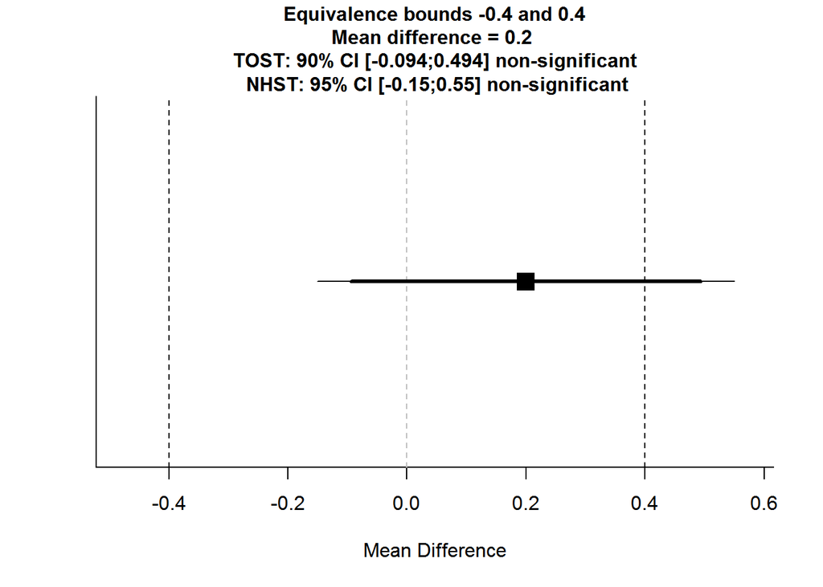

```
## TOST results:
##   t-value 1    p-value 1 t-value 2 p-value 2       df
## 1  3.379871 0.0004512547 -1.126624 0.1307575 167.2924
##
## Equivalence bounds (raw scores):
##   low bound raw high bound raw
## 1          -0.4            0.4
##
## TOST confidence interval:
##   Lower Limit 90% CI raw Upper Limit 90% CI raw
## 1            -0.09362298               0.493623
```

## *Example 1.6*

Now for the same data as example 1.5, but assuming equal variances:

### Results MiniTab Two-Sample Equivalence Test

Method

Test mean = mean of Test Reference mean = mean of Reference Equal variances were assumed for the analysis.

Descriptive Statistics

Variable N Mean StDev SE Mean Test 86 2,5 1,3 0,14018 Reference 102 2,3 1,1 0,10892

Pooled StDev = 1,19556

Difference: Mean(Test) - Mean(Reference)

Difference SE 95% CI Equivalence Interval 0,20000 0,17502 (-0,089331; 0,48933) (-0,4; 0,4)

CI is not within the equivalence interval. Cannot claim equivalence.

Test

Null hypothesis: Difference < or = -0,4 or Difference > or = 0,4 Alternative hypothesis: -0,4 < Difference < 0,4 alpha level: 0,05

Null Hypothesis DF T-Value P-Value Difference < or = -0,4 186 3,4281 0,000 Difference > or = 0,4 186 -1,1427 0,127

The greater of the two P-Values is 0,127. Cannot claim equivalence.

### Reproducing results with TOSTER

```r
TOSTtwo.raw(m1=2.5,m2=2.3,sd1=1.3, sd2=1.1,n1=86,n2=102,low_eqbound=-0.4, high_eqbound=0.4,alpha=0.05, var.equal=TRUE)
```

```
## Using alpha = 0.05 Student's t-test was non-significant, t(186) = 1.142695, p = 0.254634
```

```
## Using alpha = 0.05 the equivalence test based on Student's t-test was non-significant, t(186) = -1.142695, p = 0.127317
```

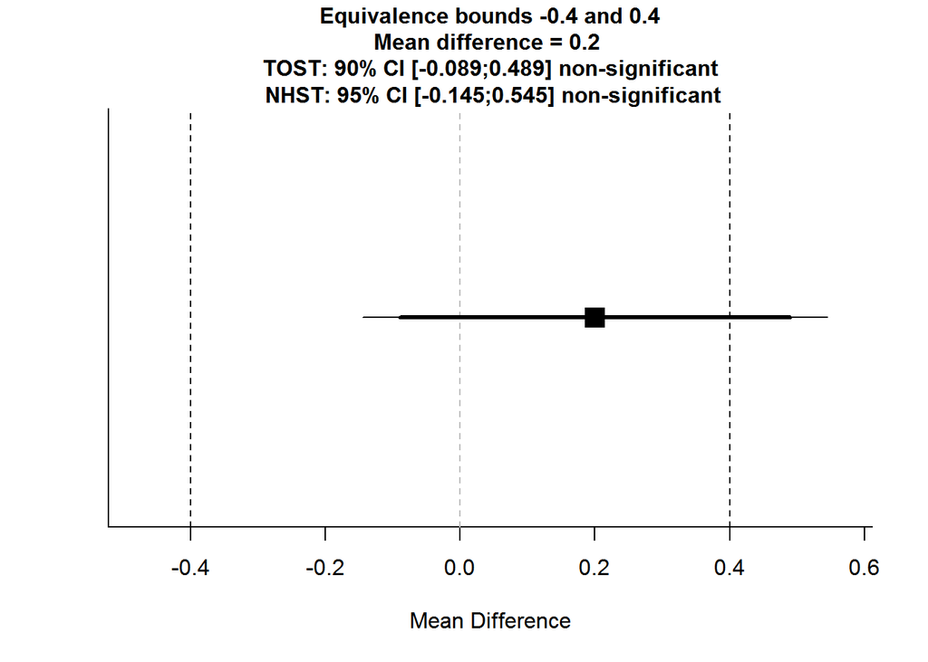

```
## TOST results:
##   t-value 1    p-value 1 t-value 2 p-value 2  df
## 1  3.428085 0.0003742019 -1.142695  0.127317 186
##
## Equivalence bounds (raw scores):
##   low bound raw high bound raw
## 1          -0.4            0.4
##
## TOST confidence interval:
##   Lower Limit 90% CI raw Upper Limit 90% CI raw
## 1            -0.08933128              0.4893313
```

```r
TOSTtwo.raw(m1=2.5,m2=2.3,sd1=1.3, sd2=1.1,n1=86,n2=102,low_eqbound=-0.4, high_eqbound=0.4,alpha=0.05)
```

```
## Using alpha = 0.05 Welch's t-test was non-significant, t(167.2924) = 1.126624, p = 0.2615151
```

```
## Using alpha = 0.05 the equivalence test based on Welch's t-test  was non-significant, t(167.2924) = -1.126624, p = 0.1307575
```

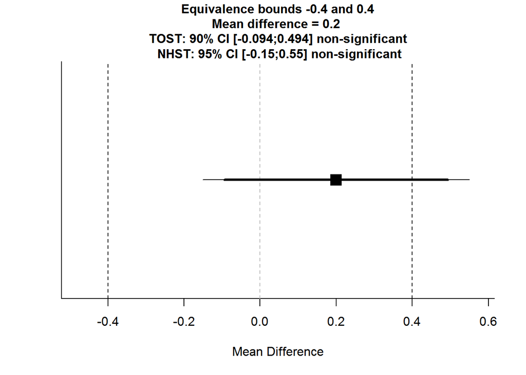

```
## TOST results:
##   t-value 1    p-value 1 t-value 2 p-value 2       df
## 1  3.379871 0.0004512547 -1.126624 0.1307575 167.2924
##
## Equivalence bounds (raw scores):
##   low bound raw high bound raw
## 1          -0.4            0.4
##
## TOST confidence interval:
##   Lower Limit 90% CI raw Upper Limit 90% CI raw
## 1            -0.09362298               0.493623
```

# **Paired t-test**

## *Example 2.1*

We can compare the TOSTpaired.raw function against the equivalence package.

Paired t-test in equivalence package (from example in tost function) and TOSTpaired.raw.

```r
require(equivalence)
data(ufc)
#Remove missing data
ufc<-ufc[complete.cases(ufc[,9:10]),]

tost(ufc$Height.m.p, ufc$Height.m, epsilon = 1, paired = TRUE)
```

```
##
##  Paired TOST
##
## data:  ufc$Height.m.p and ufc$Height.m
## df = 376
## sample estimates:
## mean of the differences
##               0.6003913
##
## Epsilon: 1
## 95 percent two one-sided confidence interval (TOST interval):
##  0.1916419 1.0091407
## Null hypothesis of statistical difference is: not rejected
## TOST p-value: 0.05389588
```

```r
TOSTpaired.raw(n=length(ufc$Height.m.p),m1=mean(ufc$Height.m.p,na.rm = TRUE), m2=mean(ufc$Height.m,na.rm = TRUE), sd1=sd(ufc$Height.m.p,na.rm = TRUE), sd2=sd(ufc$Height.m,na.rm = TRUE), r12=cor(ufc$Height.m,ufc$Height.m.p, use="pairwise.complete.obs"), low_eqbound=-1,high_eqbound=1, alpha=0.05)
```

```
## Using alpha = 0.05 the NHST t-test was significant, t(376) = 2.42201, p = 0.01590709
```

```
## Using alpha = 0.05 the equivalence test was non-significant, t(376) = -1.612042, p = 0.05389588
```

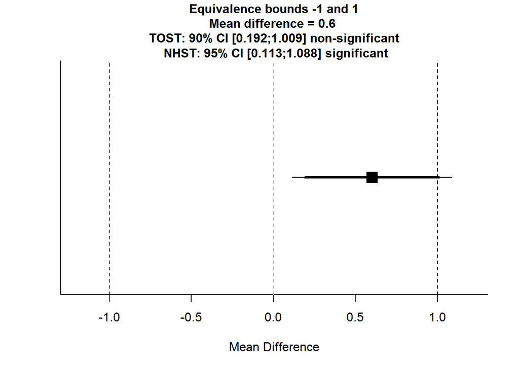

```
## TOST results:
##   t-value 1  p-value 1 t-value 2    p-value 2  df
## 1 -1.612042 0.05389588  6.456061 1.660469e-10 376
##
## Equivalence bounds (raw scores):
##   low bound raw high bound raw
## 1            -1              1
##
## TOST confidence interval:
##   Lower Limit 90% CI raw Upper Limit 90% CI raw
## 1              0.1916419               1.009141
```

## *Example 2.2*

Quertemont also provides an example for paired t-tests in the appendix (page 124): Mdif = 1, SDif = 1.58, d = .5, t = 0.71, df = 4, p = .74 with a 95% CI from -.96 to + 2.96.

```r
morning<-c(3,4,4,5,4)
evening<-c(1,4,1,4,5)

TOSTpaired.raw(n=5,m1=mean(morning), m2=mean(evening), sd1=sd(morning), sd2=sd(evening), r12=cor(morning,evening), low_eqbound=-0.5,high_eqbound=0.5, alpha=0.05)
```

```
## Using alpha = 0.05 the NHST t-test was non-significant, t(4) = 1.414214, p = 0.2301996
```

```
## Using alpha = 0.05 the equivalence test was non-significant, t(4) = 0.7071068, p = 0.7407407
```

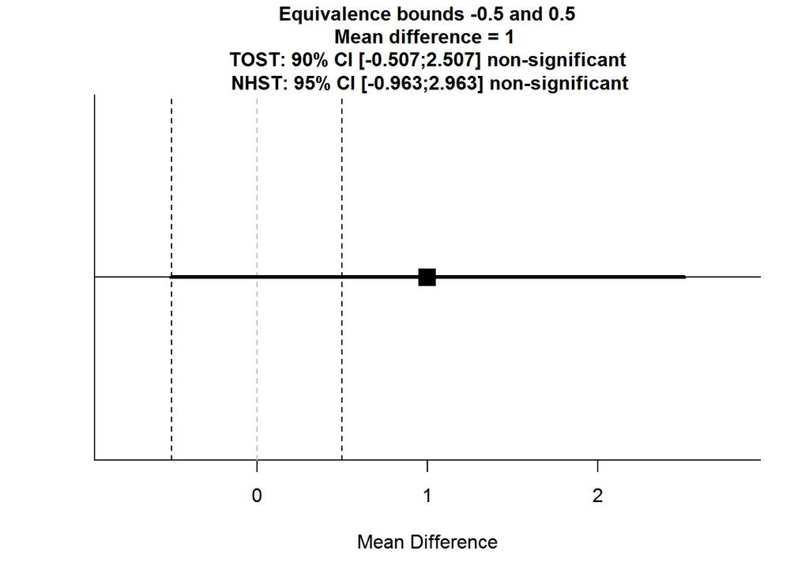

```
## TOST results:
##   t-value 1 p-value 1 t-value 2  p-value 2 df
## 1 0.7071068 0.7407407   2.12132 0.05059575  4
##
## Equivalence bounds (raw scores):
##   low bound raw high bound raw
## 1          -0.5            0.5
##
## TOST confidence interval:
##   Lower Limit 90% CI raw Upper Limit 90% CI raw
## 1             -0.5074433               2.507443
```

This output matches the calculations in Quertemont (2011).

## *Example 2.3*

MiniTab does not allow users to perform equivalence tests for paired samples t-test based on summary data, but this equivalence test can be calculated based on the raw data.

Data: DV1<-c(4,2,4,3,5,4,3,4,5,4,2,3,4,5,5) DV2<-c(3,4,2,3,5,4,3,4,5,3,4,3,2,3,4)

### Results MiniTab Equivalence Test with Paired Data: DV1, DV2

Method

Test mean = mean of DV1 Reference mean = mean of DV2

Descriptive Statistics

Variable N Mean StDev SE Mean DV1 15 3,8000 1,0142 0,26186 DV2 15 3,4667 0,91548 0,23637

Difference: Mean(DV1) - Mean(DV2)

Difference StDev SE 95% CI Equivalence Interval 0,33333 1,23443 0,31873 (-0,22804; 0,89471) (-0,8; 0,8)

CI is not within the equivalence interval. Cannot claim equivalence.

Test

Null hypothesis: Difference < or = -0,8 or Difference > or = 0,8 Alternative hypothesis: -0,8 < Difference < 0,8 alpha level: 0,05

Null Hypothesis DF T-Value P-Value Difference < or = -0,8 14 3,5558 0,002 Difference > or = 0,8 14 -1,4642 0,083

The greater of the two P-Values is 0,083. Cannot claim equivalence.

### Reproduce Results with TOSTER

```r
DV1<-c(4,2,4,3,5,4,3,4,5,4,2,3,4,5,5)
DV2<-c(3,4,2,3,5,4,3,4,5,3,4,3,2,3,4)

TOSTpaired.raw(n=length(DV1),m1=mean(DV1), m2=mean(DV2), sd1=sd(DV1), sd2=sd(DV2), r12=cor(DV1,DV2), low_eqbound=-0.8,high_eqbound=0.8, alpha=0.05)
```

```
## Using alpha = 0.05 the NHST t-test was non-significant, t(14) = 1.045825, p = 0.3133636
```

```
## Using alpha = 0.05 the equivalence test was non-significant, t(14) = -1.464155, p = 0.08262144
```

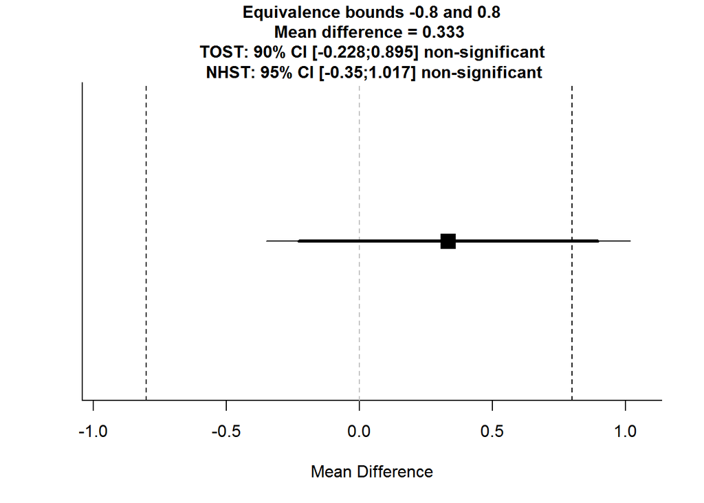

```
## TOST results:
##   t-value 1  p-value 1 t-value 2  p-value 2 df
## 1 -1.464155 0.08262144  3.555805 0.00158212 14
##
## Equivalence bounds (raw scores):
##   low bound raw high bound raw
## 1          -0.8            0.8
##
## TOST confidence interval:
##   Lower Limit 90% CI raw Upper Limit 90% CI raw
## 1             -0.2280449              0.8947115
```

# **One-sample t-test**

## *Example 3.1*

### Result MiniTab One-Sample Equivalence Test

Method

Target = 0

Descriptive Statistics

N Mean StDev SE Mean 100 -0,3 1 0,10000

Difference: Mean - Target

Difference SE 95% CI Equivalence Interval -0,30000 0,10000 (-0,46604; 0) (-0,5; 0,5)

CI is within the equivalence interval. Can claim equivalence.

Test

Null hypothesis: Difference < or = -0,5 or Difference > or = 0,5 Alternative hypothesis: -0,5 < Difference < 0,5 alpha level: 0,05

Null Hypothesis DF T-Value P-Value Difference < or = -0,5 99 2,0000 0,024 Difference > or = 0,5 99 -8,0000 0,000

The greater of the two P-Values is 0,024. Can claim equivalence.

### Reproduce with TOSTER:

```r
TOSTone.raw(m=-0.3,mu=0.0,sd=1,n=100,low_eqbound=-0.5, high_eqbound=0.5, alpha=0.05)
```

```
## Using alpha = 0.05 the NHST one-sample t-test was significant, t(99) = -3, p = 0.003415508
```

```
## Using alpha = 0.05 the equivalence test was significant, t(99) = 2, p = 0.02411985
```

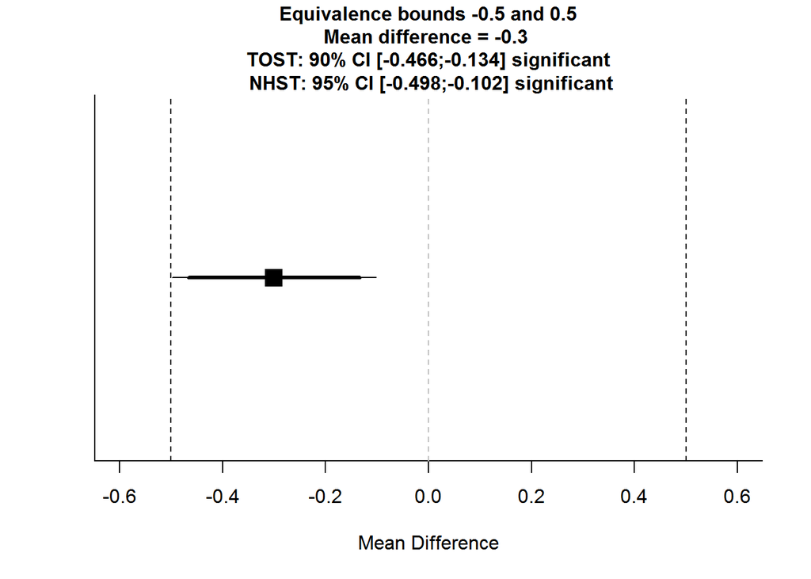

```
## TOST results:
##   t-value 1  p-value 1 t-value 2    p-value 2 df
## 1         2 0.02411985        -8 1.200152e-12 99
##
## Equivalence bounds (raw scores):
##   low bound raw high bound raw
## 1          -0.5            0.5
##
## TOST confidence interval:
##   Lower Limit 90% CI raw Upper Limit 90% CI raw
## 1             -0.4660391             -0.1339609
```

Which should be identical to the TOSTone test (because when SD = 1, unstandardized scores equal standardized scores)

```r
TOSTone(m=-0.3,mu=0.0,sd=1,n=100,low_eqbound_d=-0.5, high_eqbound_d=0.5, alpha=0.05)
```

```
## Using alpha = 0.05 the NHST one-sample t-test was significant, t(99) = -3, p = 0.003415508
```

```
## Using alpha = 0.05 the equivalence test was significant, t(99) = 2, p = 0.02411985
```

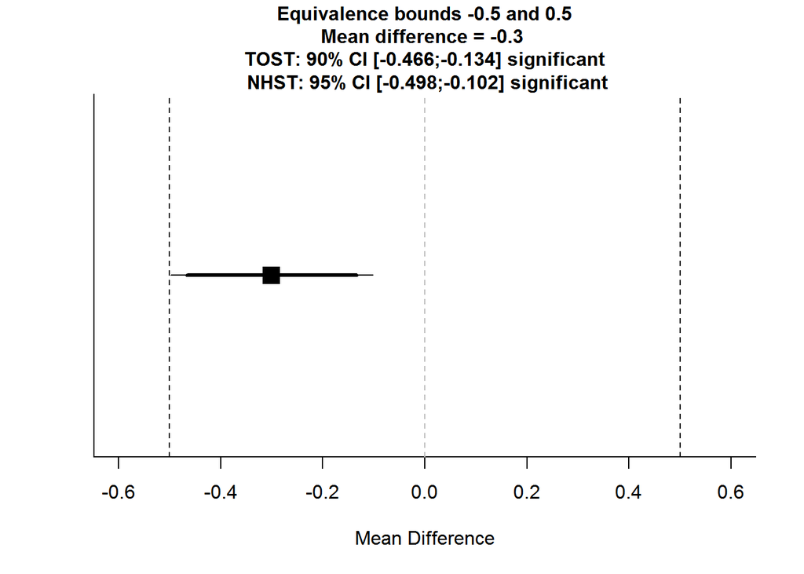

```
## TOST results:
##   t-value 1  p-value 1 t-value 2    p-value 2 df
## 1         2 0.02411985        -8 1.200152e-12 99
##
## Equivalence bounds (Cohen's d):
##   low bound d high bound d
## 1        -0.5          0.5
##
## Equivalence bounds (raw scores):
##   low bound raw high bound raw
## 1          -0.5            0.5
##
## TOST confidence interval:
##   Lower Limit 90% CI raw Upper Limit 90% CI raw
## 1             -0.4660391             -0.1339609
```

## *Example 3.2*

### MiniTab Result One-Sample Equivalence Test

Method

Target = 0

Descriptive Statistics

N Mean StDev SE Mean 100 1 1,2 0,12000

Difference: Mean - Target

Difference SE 95% CI Equivalence Interval 1,0000 0,12000 (0; 1,1992) (-0,8; 0,8)

CI is not within the equivalence interval. Cannot claim equivalence.

Test

Null hypothesis: Difference < or = -0,8 or Difference > or = 0,8 Alternative hypothesis: -0,8 < Difference < 0,8 alpha level: 0,05

Null Hypothesis DF T-Value P-Value Difference < or = -0,8 99 15,000 0,000 Difference > or = 0,8 99 1,6667 0,951

The greater of the two P-Values is 0,951. Cannot claim equivalence.

### Reproducing the results with TOSTER

```r
TOSTone.raw(m=-1,mu=0.0,sd=1.2,n=100,low_eqbound=-0.8, high_eqbound=0.8, alpha=0.05)
```

```
## Using alpha = 0.05 the NHST one-sample t-test was significant, t(99) = -8.333333, p = 4.611473e-13
```

```
## Using alpha = 0.05 the equivalence test was non-significant, t(99) = -1.666667, p = 0.9506292
```

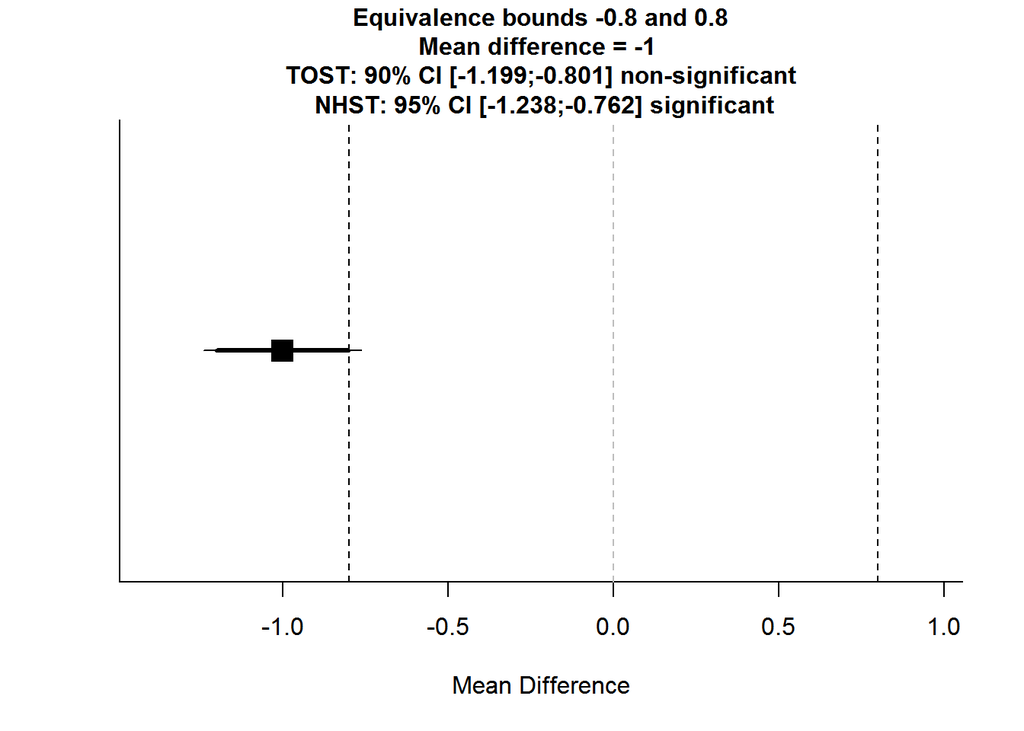

```
## TOST results:
##   t-value 1 p-value 1 t-value 2    p-value 2 df
## 1 -1.666667 0.9506292       -15 1.553349e-27 99
##
## Equivalence bounds (raw scores):
##   low bound raw high bound raw
## 1          -0.8            0.8
##
## TOST confidence interval:
##   Lower Limit 90% CI raw Upper Limit 90% CI raw
## 1              -1.199247             -0.8007531
```

# **Equivalence test for correlations**

## *Example 4.1*

Quertemont (2011) provides an example in the appendix (page 126): Suppose a sample with N = 50, r = .1, and d = .2, and calculated that p(Z < -0.70) = .24. The confidence interval for r is -0.18 to 0.37

We can reproduce this result using the TOSTr function:

```r
TOSTr(n=50, r = 0.1, low_eqbound_r=-0.2, high_eqbound_r=0.2, alpha=0.05)
```

```
## Using alpha = 0.05 the NHST t-test was non-significant, p = 0.4895926
```

```
## Using alpha = 0.05 the equivalence test was non-significant, p = 0.2413396
```

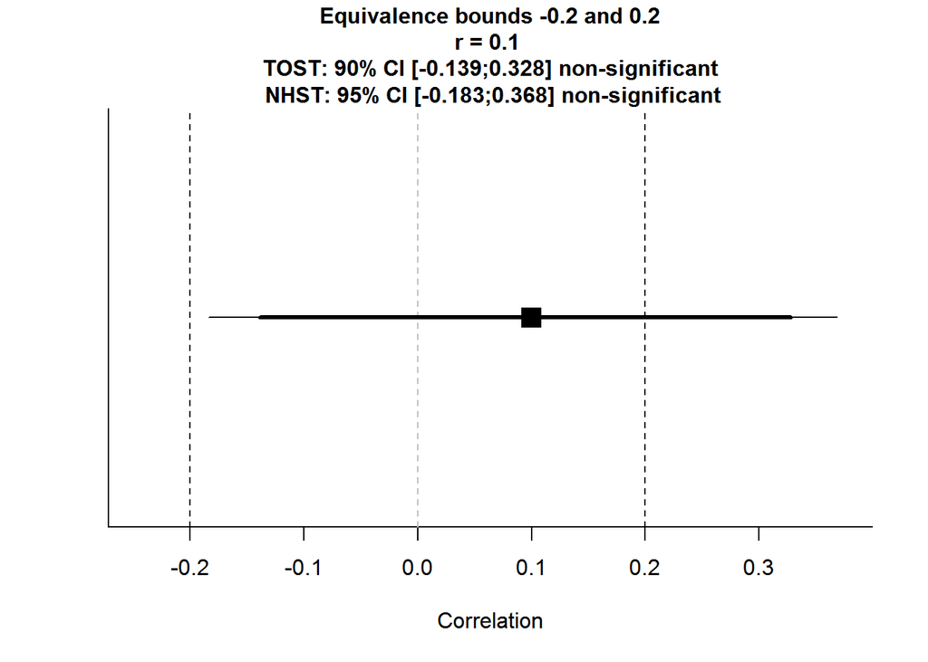

```
## TOST results:
##   p-value 1  p-value 2
## 1 0.2413396 0.01886717
##
## Equivalence bounds (r):
##   low bound r high bound r
## 1        -0.2          0.2
##
## TOST confidence interval:
##   Lower Limit 90% CI raw Upper Limit 90% CI raw
## 1             -0.1386915              0.3277112
```

The resulting p-value and 95% CI match the calculations by Quertemont (2011).

## *Example 4.2*

The R code from Goertzen & Cribbie, page 536, was used:

```r
#Running an original two t test procedure for equivalence
#######
equivint<-0.3
corxy<-0.02
n<-100
alpha<-0.05

zei <-log((1 + equivint)/(1 - equivint))/2
zcorxy <-log((1 + corxy)/(1-corxy))/2
equivt1_fz <-(zcorxy - zei)/(1/sqrt(n - 3))
pvalue1_fz <-pnorm(equivt1_fz)
equivt2_fz <-(zcorxy + zei)/(1/sqrt(n - 3))
pvalue2_fz <-1 - pnorm(equivt2_fz)
ifelse (pvalue1_fz <= alpha & pvalue2_fz <= alpha, decis_fz <-"The null hypothesis that the correlation between var1 and var2 falls outside of the equivalence interval can be rejected.", decis_fz <-"The null hypothesis that the correlation between var1 and var2 falls outside of the equivalence interval cannot be rejected.")
```

```
## [1] "The null hypothesis that the correlation between var1 and var2 falls outside of the equivalence interval can be rejected."
```

```r
pvalue1_fz
```

```
## [1] 0.002176282
```

```r
pvalue2_fz
```

```
## [1] 0.0005863917
```

```r
TOSTr(n=100, r = 0.02, low_eqbound_r=-0.3, high_eqbound_r=0.3, alpha=0.05)
```

```
## Using alpha = 0.05 the NHST t-test was non-significant, p = 0.8434322
```

```
## Using alpha = 0.05 the equivalence test was significant, p = 0.002176282
```

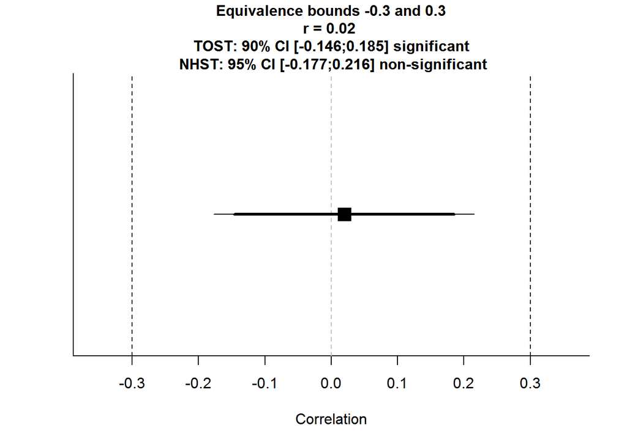

```
## TOST results:
##     p-value 1    p-value 2
## 1 0.002176282 0.0005863917
##
## Equivalence bounds (r):
##   low bound r high bound r
## 1        -0.3          0.3
##
## TOST confidence interval:
##   Lower Limit 90% CI raw Upper Limit 90% CI raw
## 1              -0.145957              0.1848622
```

# **Meta-analaysis based on Cohen’s d**

## *Example 5.1*

We can reproduce an example for a meta-analysis from From Rogers, J. L., Howard, K. I., & Vessey, J. T. (1993). Using significance tests to evaluate equivalence between two experimental groups. Psychological Bulletin, 113(3), page 557.

For example, we obtain the following calculations for the cognitive versus behavioral contrast. Traditional z: z = ES/SE = 0.12/0.09 = 1.333, p = .091. Traditional confidence interval: ES ± (za/2)(SE) = 0.12 ± (1.96)(0.09), or -0.056 to 0.296. Equivalence z: z1 = (ES + 0.20)/SE = (0.12 + 0.20)/0.09 = 3.556, p = .000. z2 = (ES - Q.2Q)/SE = (0.12 - 0.20)/0.09 = -0.889, p= .187. So we table the larger p value of 0.187. Equivalence confidence interval: ES ± (za)(SE) = 0.12 ± (1.645)(0.09), or -0.028 to 0.268.

We can recreate this with the TOSTmeta function:

```r
TOSTmeta(ES=0.12, var=0.0081, se=0.09, low_eqbound_d=-0.2, high_eqbound_d=0.2, alpha=0.05)
```

```
## Using alpha = 0.05 the meta-analysis was non-significant, Z = 1.333333, p = 0.09121122
```

```
## Using alpha = 0.05 the equivalence test was non-significant, Z = -0.8888889, p = 0.1870314
```

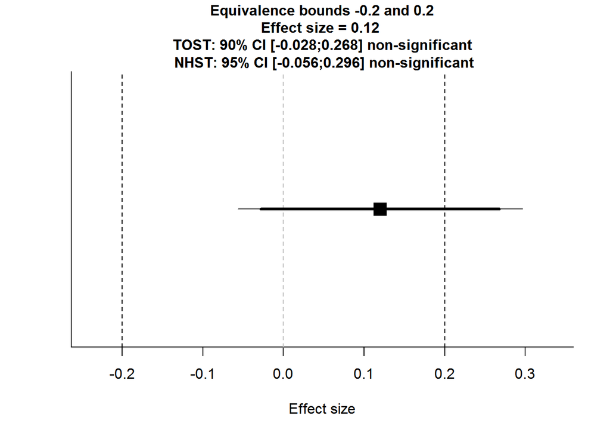

```
## TOST results:
##   Z-value 1    p-value 1  Z-value 2 p-value 2
## 1  3.555556 0.0001885906 -0.8888889 0.1870314
##
## Equivalence bounds (Cohen's d):
##   low bound d high bound d
## 1        -0.2          0.2
##
## TOST confidence interval:
##   Lower Limit 90% CI Upper Limit 90% CI
## 1        -0.02803683          0.2680368
```